# Spinal Cord Data Preparation and Simple Processing Example

Author

Affiliation

Griffen Wakelin

[Dalhousie University](https://www.dal.ca)

Published

February 4, 2024

Modified

February 5, 2024

This notebook gives a quick example of how you could download, prepare, and process data from a publication. In this example, I used data from [Milich *et al*](https://doi.org/10.1084/jem.20210040)., 2021, **Single-cell analysis of the cellular heterogeneity and interactions in the injured mouse spinal cord**, but in theory it could be done using any dataset from any paper.

## Obtaining and preparing the data

### Downloading data from GEO

The data was downloaded from the [GEO repository](https://www.ncbi.nlm.nih.gov/geo/query/acc.cgi?acc=GSE162610) associated with the publication, which is linked in the “Data Availability” section on the publication’s webpage. All reputable journals in the current era have something similar.

If you scroll down to the bottom of the GEO page, you will see a table containing “Supplementary Files”. I downloaded the files titled:

- `GSE162610_barcode_metadata.tsv.gz`
- `GSE162610_barcodes.tsv.gz`
- `GSE162610_gene_metadata.tsv.gz`
- `GSE162610_genes.tsv.gz`
- `GSE162610_sci_mat.mtx.gz`

Note that to download supplementary files on GEO, you just click the “(http)” in the column titled “Download” for the corresponding entry.

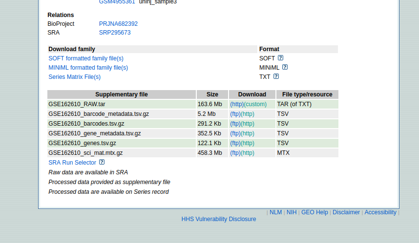

geo-downloads

### Coercing the data into the proper format

From here, I then used functions from the python packages `pandas` and `scipy` to import and reformat the data, and functions from the python package `anndata` to save the data in a format amenable for single-cell RNA-seq (the “`anndata`”/`adata` format). This is shown in the file below titled `prepare_data.py`.

```
prepare_data.py
```

```python
import pandas as pd
from scipy.io import mmread
from anndata import AnnData

obs_meta = pd.read_csv("GSE162610_barcode_metadata.tsv.gz", delimiter = "\t")
var_meta = pd.read_csv("GSE162610_gene_metadata.tsv.gz", delimiter = "\t")
counts = mmread("GSE162610_sci_mat.mtx.gz").tocsr().T

adata = AnnData(X=mat, obs=obs_meta, var=var_meta)
adata.write("milich.h5ad")
```

**1**

Loads relevant libraries for executing this script.

**2**

Loads in the file containing cell-level metadata.

**3**

Loads in the file containing the gene-level metadata.

**4**

Loads in the counts matrix.

**5**

Creates the `anndata` object.

**6**

Saves the `anndata` object.

Note that the methods I used above to make the final `milich.h5ad` file are specific to this dataset and will not work with any others. This is why it’s important to learn the very basics of python so that you can perform such tasks trivially.

## (Pre)processing the data

I have saved the original data from the Milich *et al*. publication in your home directories in a folder called “GSE162610”, along with the `milich.h5ad` file. You can load the `.h5ad` file into python by importing `scanpy` and using its function `read_h5ad()` as follows:

```python
# import libraries
import scanpy as sc
import warnings
warnings.filterwarnings("ignore")

adata = sc.read_h5ad("GSE162610/milich.h5ad") # load in the data
```

You can view the cell- (obs) or gene-level (var) metadata of the `adata` object using the `adata.obs` or `adata.var` methods, respectively:

```python
adata.obs
```

|  | orig.ident | nCount_RNA | nFeature_RNA | S.Score | G2M.Score | Phase | CC.Difference | nCount_SCT | nFeature_SCT | sample_id | ... | percent_rp | pass_percent_rp | percent_hbb | pass_percent_hbb | doublet_scores | is_doublet | integrated_snn_res.0.8 | seurat_clusters | default_cluster | celltype |
| --- | --- | --- | --- | --- | --- | --- | --- | --- | --- | --- | --- | --- | --- | --- | --- | --- | --- | --- | --- | --- | --- |
| AAACCTGAGAAGGGTA_1dpi_sample1 | 1dpi_sample1 | 2963 | 1562 | -0.114955 | -0.080684 | G1 | -0.034271 | 4626 | 1582 | 1dpi_sample1 | ... | 0.093455 | True | 0.000000 | True | 0.006201 | False | 3 | 3 | 3 | Endothelial |
| AAACCTGAGAATGTTG_1dpi_sample1 | 1dpi_sample1 | 5031 | 2105 | -0.030511 | -0.093308 | G1 | 0.062797 | 5137 | 2105 | 1dpi_sample1 | ... | 0.118418 | True | 0.000000 | True | 0.009843 | False | 3 | 3 | 3 | Endothelial |
| AAACCTGAGACGCAAC_1dpi_sample1 | 1dpi_sample1 | 15277 | 3364 | 0.124416 | 0.425777 | G2M | -0.301362 | 5540 | 1899 | 1dpi_sample1 | ... | 0.171096 | True | 0.000000 | True | 0.127497 | False | 29 | 29 | 29 | Div-Myeloid |
| AAACCTGAGCAATATG_1dpi_sample1 | 1dpi_sample1 | 4585 | 1019 | -0.062800 | -0.010219 | G1 | -0.052581 | 5057 | 1019 | 1dpi_sample1 | ... | 0.026390 | False | 0.000000 | True | 0.022712 | False | 14 | 14 | 14 | Neutrophil |
| AAACCTGAGGACAGCT_1dpi_sample1 | 1dpi_sample1 | 11975 | 3138 | 0.333207 | 0.191388 | S | 0.141819 | 5923 | 2553 | 1dpi_sample1 | ... | 0.353290 | True | 0.000084 | True | 0.089927 | False | 15 | 15 | 15 | Div-Myeloid |
| ... | ... | ... | ... | ... | ... | ... | ... | ... | ... | ... | ... | ... | ... | ... | ... | ... | ... | ... | ... | ... | ... |
| TTTGTTGAGAATACAC_uninj_sample3 | uninj_sample3 | 4599 | 1895 | -0.013252 | -0.007464 | G1 | -0.005787 | 7337 | 1897 | uninj_sample3 | ... | 0.105847 | True | 0.000000 | True | 0.021030 | False | 6 | 6 | 6 | Endothelial |
| TTTGTTGCAGTACTAC_uninj_sample3 | uninj_sample3 | 15700 | 4746 | 0.035824 | 0.033421 | S | 0.002404 | 8794 | 3983 | uninj_sample3 | ... | 0.090759 | True | 0.000000 | True | 0.024152 | False | 7 | 7 | 7 | Ependymal |
| TTTGTTGGTAAGCAAT_uninj_sample3 | uninj_sample3 | 9030 | 3795 | 0.041746 | -0.084748 | S | 0.126494 | 8536 | 3794 | uninj_sample3 | ... | 0.069752 | True | 0.000000 | True | 0.021030 | False | 12 | 12 | 12 | OPC |
| TTTGTTGTCACCTGTC_uninj_sample3 | uninj_sample3 | 11438 | 3516 | 0.020627 | -0.044879 | S | 0.065507 | 8541 | 3510 | uninj_sample3 | ... | 0.102508 | True | 0.000000 | True | 0.043727 | False | 3 | 3 | 3 | Endothelial |
| TTTGTTGTCACTTATC_uninj_sample3 | uninj_sample3 | 7636 | 2636 | 0.007830 | -0.068450 | S | 0.076280 | 7700 | 2636 | uninj_sample3 | ... | 0.083290 | True | 0.000000 | True | 0.026155 | False | 2 | 2 | 2 | Microglia |

66178 rows × 29 columns

### General Processing Workflow

We can see that the authors provided important metadata such as their annotated cell type (`celltype`), condition (`sample_id`), cell-cycle phase (`Phase`), etc. We can look further into these later, but we must first process the data. To simplify this, we will subset the data to only contain a single condition.

```python
adata.obs.sample_id.cat.categories
```

```
Index(['1dpi_sample1', '1dpi_sample2', '1dpi_sample3', '3dpi_sample1',
       '3dpi_sample2', '7dpi_sample1', '7dpi_sample2', 'uninj_sample1',
       'uninj_sample2', 'uninj_sample3'],
      dtype='object')
```

```python
adata_uninj_sample1 = adata[adata.obs['sample_id']=='uninj_sample1', :]
```

Single-cell RNA-seq data processing follows a fairly standardized workflow due to its properties, mainly that it is count data and extremely sparse. Here I quickly define a function `quick_preprocess()` to run through the standard workflow.

```python
def quick_preprocess(adata):
    adata_pp = adata.copy()
    adata_pp.layers['counts'] = adata.X.copy()
    sc.pp.normalize_total(adata_pp, target_sum=1e6)
    sc.pp.log1p(adata_pp)
    sc.pp.pca(adata_pp)
    sc.pp.neighbors(adata_pp)
    sc.tl.leiden(adata_pp)
    sc.tl.umap(adata_pp)
    return adata_pp
```

We can then run this function using the `adata_uninjured_sample1` anndata object from before, and plot the results of clustering.

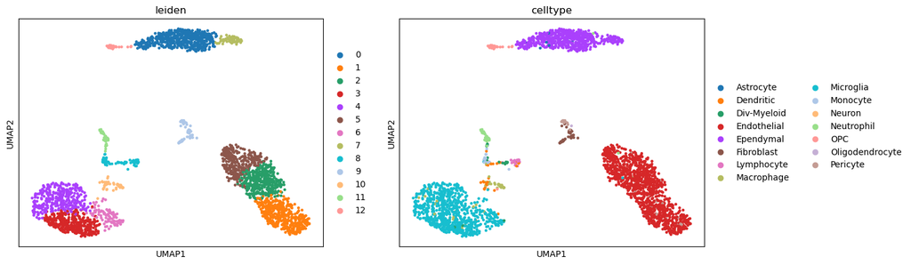

```python
adata_uninj_sample1 = quick_preprocess(adata_uninj_sample1)
sc.pl.umap(adata_uninj_sample1, color=['leiden','celltype'], ncols=2)
```

The results from our quick preprocessing are similar, but not identical to their cell types. For example, clusters `1`, `2`, and `5` from our preprocessing are all contained within their `Endothelial` cluster. Let us consider their annotations as ground truth. If we want our annotations to get closer to theirs, we can recluster using a few different `resolution` parameters.

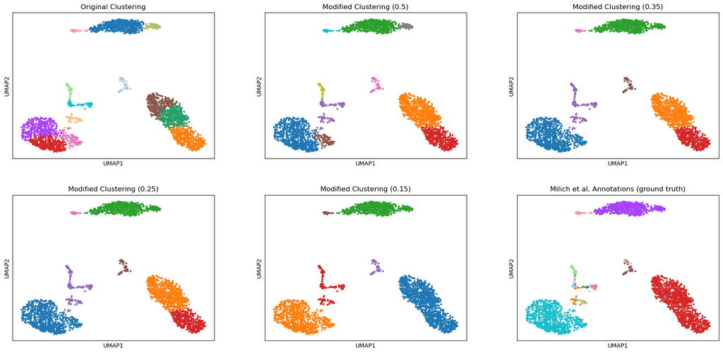

```python
for res in [0.5, 0.35, 0.25, 0.15]:
    sc.tl.leiden(adata_uninj_sample1, resolution=res, key_added=f'leiden_{res}')

sc.pl.umap(
    adata_uninj_sample1,
    color=[
    'leiden',
    'leiden_0.5',
    'leiden_0.35',
    'leiden_0.25',
    'leiden_0.15',
    'celltype'
    ],
    title=[
        'Original Clustering',
        'Modified Clustering (0.5)',
        'Modified Clustering (0.35)',
        'Modified Clustering (0.25)',
        'Modified Clustering (0.15)',
        'Milich et al. Annotations (ground truth)'
    ],
    legend_loc=None,
    ncols=3
)
```

Using `resolution=0.15` recapitulates the ground truth clustering fairly closely, and could be picked as a resolution to use for more downstream analyses.

We compare the datasets side-by-side and rename our clusters accordingly (while collapsing some clusters into one).

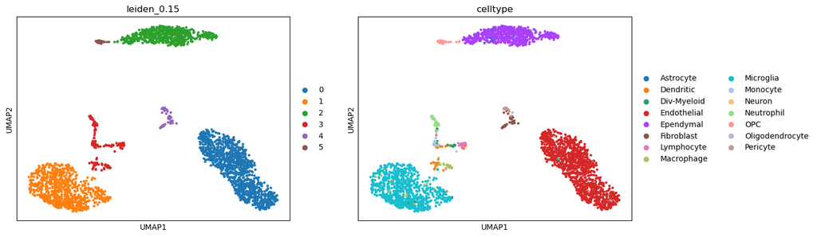

```python
sc.pl.umap(adata_uninj_sample1, color=['leiden_0.15','celltype'])
```

```python
new_clusters = [
    'Endothelial',
    'Microglia',
    'Ependymal',
    'Immune',
    'FibroPeri',
    'OPC',
]
adata_uninj_sample1.obs['leiden_0.15'] = adata_uninj_sample1.obs['leiden_0.15'].cat.rename_categories(new_clusters)
```

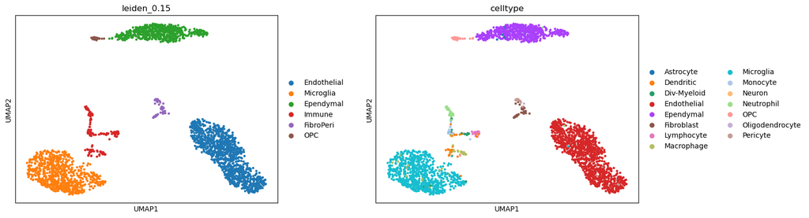

```python
sc.pl.umap(adata_uninj_sample1, color=['leiden_0.15','celltype'], wspace=0.25)
```

Now, if we wanted to know which genes were differentially expressed between the clusters, we could perform such tests.

```python
sc.tl.rank_genes_groups(adata_uninj_sample1, groupby='leiden_0.15', method='wilcoxon')
df = sc.get.rank_genes_groups_df(adata_uninj_sample1, group=None)
```

We can manipulate the dataframe containing the results of the differential expression testing, `df`. For example, we could view the top 5 differentially-expressed genes in the OPC cluster, sorted by Benjamini-Hochberg-corrected P-values:

```python
df[df['group']=='OPC'].sort_values('pvals_adj', ascending=True).head(5)
```

|  | group | names | scores | logfoldchanges | pvals | pvals_adj |
| --- | --- | --- | --- | --- | --- | --- |
| 165885 | OPC | Rtn1 | 8.548459 | 10.125089 | 1.247426e-17 | 4.138584e-13 |
| 165886 | OPC | Gpm6b | 8.349356 | 9.845983 | 6.863645e-17 | 9.533413e-13 |
| 165887 | OPC | Olig1 | 8.279991 | 15.367180 | 1.231844e-16 | 9.533413e-13 |
| 165888 | OPC | Scrg1 | 8.279263 | 14.186630 | 1.239407e-16 | 9.533413e-13 |
| 165889 | OPC | Pcsk1n | 8.261648 | 9.420261 | 1.436750e-16 | 9.533413e-13 |

```python
import pandas as pd
pd.DataFrame(adata_uninj_sample1.uns['rank_genes_groups']['names']).head(5)
```

|  | Endothelial | Microglia | Ependymal | Immune | FibroPeri | OPC |
| --- | --- | --- | --- | --- | --- | --- |
| 0 | Bsg | Hexb | Mt3 | Cd52 | Pcolce | Rtn1 |
| 1 | Cldn5 | Cst3 | Dbi | Lyz2 | Lgals1 | Gpm6b |
| 2 | Ly6c1 | Ctsd | Nnat | Pfn1 | Gsn | Olig1 |
| 3 | Itm2a | Ctss | Mt1 | Arhgdib | Nbl1 | Scrg1 |
| 4 | Flt1 | C1qb | Clu | Rac2 | Nupr1 | Pcsk1n |

Importantly, this shows us that our annotations were at least somewhat accurate, as genes known to be associated with certain cell types are upregulated in their respective clusters. For example, *Hexb* is [known to be](https://www.frontiersin.org/articles/10.3389/fncel.2022.808598/full) a marker for microglia, and has the highest Z-score in the microglial cluster. Similarly, *Olig1* is seen to be differentially expressed in the OPC cluster.

We can visualize some of these genes using a few different methods, which further increases our confidence in the cell type annotations:

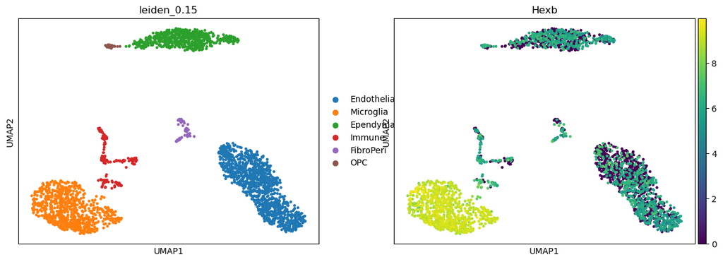

```python
sc.pl.umap(adata_uninj_sample1, color=['leiden_0.15', 'Hexb'])
```

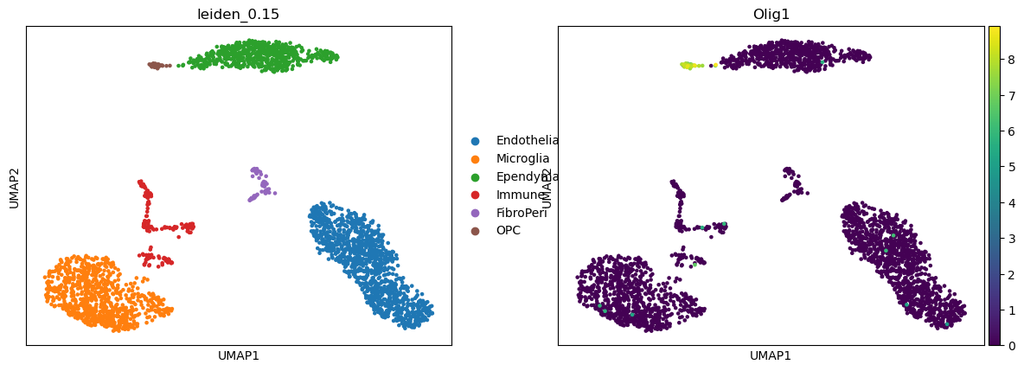

```python
sc.pl.umap(adata_uninj_sample1, color=['leiden_0.15', 'Olig1'])
```

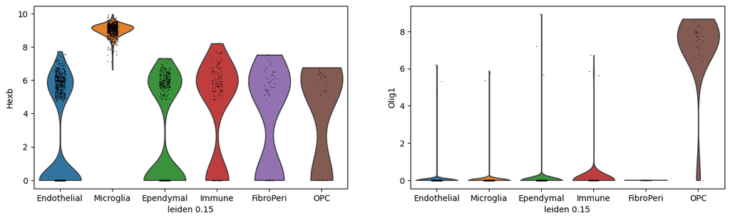

```python
import matplotlib.pyplot as plt

fig, ax = plt.subplots(1, 2, figsize=(15,4))
sc.pl.violin(adata_uninj_sample1, groupby='leiden_0.15', keys=['Hexb'], show=False, ax=ax[0])
sc.pl.violin(adata_uninj_sample1, groupby='leiden_0.15', keys=['Olig1'], show=False, ax=ax[1])
plt.show()
```

## Next Steps

There are numerous possibilities for analyses from here onwards, but you can take a look at some resources such as [scanpy’s tutorials](https://scanpy.readthedocs.io/en/stable/tutorials.html) for some basic ideas. Feel free to ask me any theoretical or practical questions related to single-cell or programming as I am happy to answer.